## Programación para principiantes con Python

# Introducción a la resolución de problemas

### 1. Objetivo

En ésta unidad, lo que queremos mostrarte son algunas técnicas que puedes usar cuando requieres encontrar la solución a un problema. La idea es que antes de codificar encuentres la solución.

### 2. Introducción

En muchos ámbitos de la vida, se nos presentan situaciones a las que debemos darle solución. Y aunque no nos demos cuenta, generalmente seguimos una serie de pasos (mentales) para encontrar la solución óptima a nuestro problema.

1. **El Qué?** Es la pregunta de investigación.
2. **El Cómo?** Analizas el problema, ves las opciones, los pro y los contra, las variables a tomar en cuenta para que tomes la mejor decisión.
3. **La Alternativa** La hipótesis es la alternativa que quieres probar para responder el qué. Después de análisis que has hecho, esta opción es la mejor de todas.
4. **El Hacer** Pones manos a la obra y haces el experimento.
5. **Los Resultados** Observas si tu decisión fue correcta en base a lo que observas, o si es necesario corregir.

### 3. Desarrollo de software

Una constante en proyectos de bioinformática y biología computacional es el uso de herramientas matemáticas para extraer información útil de datos producidos por técnicas biológicas. Las áreas más comunes donde se aplica la bioinformática son el análisis de secuencias resguardadas en bases de datos, la anotación de genomas, la comparación evolutiva de genomas, la dinámica poblacional, el análisis de expresión génica, el análsis de regulación genética, el análisis de mutaciones, la predicción de estructuras de proteinas, etc ( ver https://es.wikipedia.org/wiki/Bioinform%C3%A1tica).

La cantidad de información resguardada en bases de datos es enorme, o incluso los archivos de datos resultados de un experimento usando tecnologías de última generación son muy grandes y un análisis manual de la información sin errores resulta casi imposible.

Generalmente, en un proyecto para el análisis de datos biológicos incluye todo un **pipeline** o flujo de ejecución de varios programas que hacen “algo” y producen más datos durante el proceso de análisis. Muchas de las tareas incluyen el **formateo de datos** para pasar el resultado de un programa como entrada de datos a otro. Y en algunas ocasiones requeriremos desarrollar **scripts** en **unix** o **programas** en algún **lenguaje de programación** que nos permitan o bien formatear datos o realizar algún cálculo o análisis.

Sea que tengamos que hacer un **programa** para una tarea pequeña o bien para hacer un análisis complejo, es recomendable seguir la misma metodología para la solución de problemas. Aunque cuando se crea un programa o software los nombres de las etapas son identificadas como Requisitos, Análisis, Diseño, Codificación y Pruebas, como lo ilustra la siguiente figura.

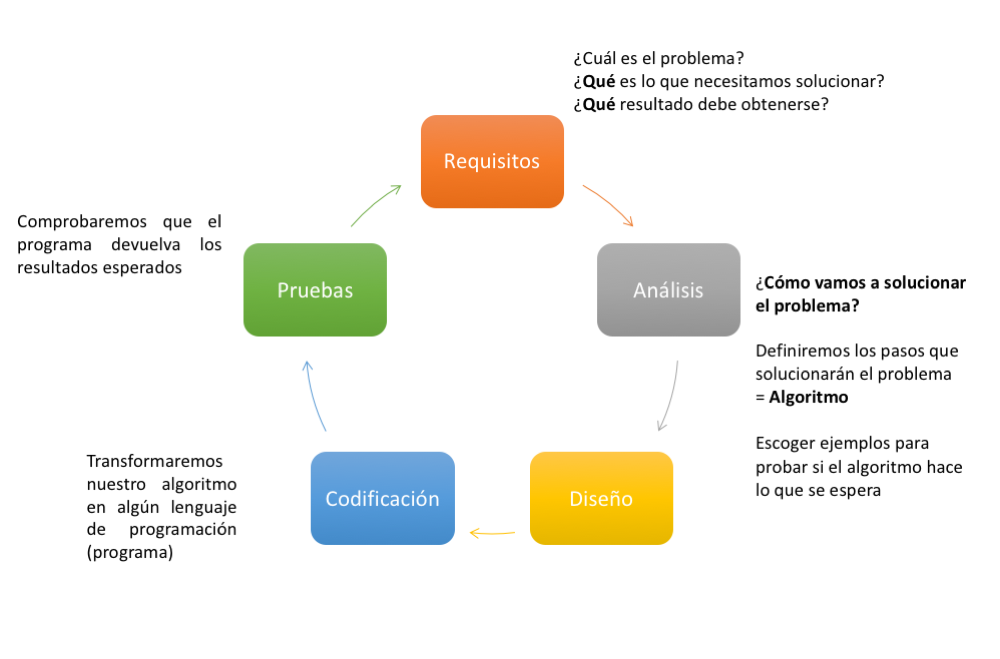

#### Requisitos

En esta etapa hay que identificar **qué** se necesita, que se requiere que haga el programa, cúal es el problema a abordar, qué pretendo solucionar. Los requisitos pueden ser de dos tipos: funcionales y no funcionales.

*Funcionales*

- Características de los servicios que debe proporcionar el sistema: ¿Cómo se debe comportar?
- Características requeridas del sistema que expresen una capacidad de acción del mismo: funcionalidad.
- Describen lo que el sistema debe hacer: flujo de trabajo, entradas, salidas, excepciones.

*No funcionales*

- No se refieren directamente a la funcionalidad, sino a las propiedades del sistema: tiempo de respuesta, capacidad de almacenamiento, seguridad.
- Cualidades que se imponen al proyecto: lenguaje de programación, plataforma tecnológica, estándares de calidad (MoProSoft).

Técnicas para obtener los requisitos:

- Entrevistas
- Cuestionarios
- Observación

Entregables:

Documento que contenga la

- Lista de requisitos
- Casos de uso

```
Ejemplo: Hacer un programa que sume numeros

¿fácil?
¿cuáles son los requisitos?
¿es suficiente con eso?
```

#### Análisis y diseño

Consiste en:

- Estudiar y entender los requisitos para proponer una solución a implementarse
- Buscar la mejor solución al problema
- Identificar toda la información de entrada y salida del sistema
- Establecer características de las interfaces de usuario
- Definir restricciones en los datos
- Definir cómo se visualizarán los datos
- Etcétera

Herramientas y Técnicas:

- Reuniones de trabajo
- Lluvia de ideas
- Entrevistas
- Modelado (UML)
  - Diagramas de comportamiento:
    - Use Case Diagram (used by some methodologies during requirements gathering)
    - Activity Diagram
    - State Machine Diagram
  - Diagramas de interacción:
    - Sequence Diagram
    - Communication Diagram
    - Timing Diagram
    - Interaction Overview Diagram
- Bosquejos/Prototipos visuales (mockups)

Entregables:

Documento de Análisis y Diseño conteniendo:

- Diagramas
- Bosquejos o Prototipos

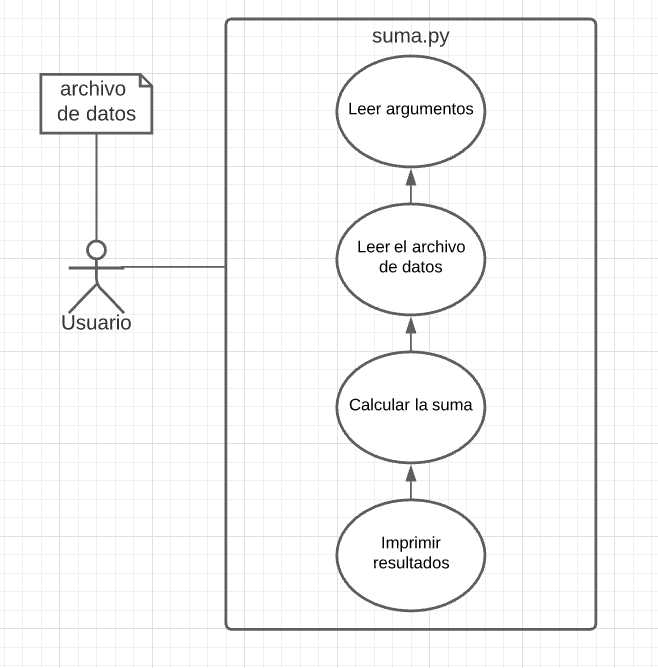

#### Codificación

Traducir el diseño en un lenguaje de programación y tecnología específicos.

Seleccionar:

- Lenguajes de programación
- Paradigma de programación
- Estándares de programación
- Infraestructura de desarrollo
- Interfaces de desarrollo integrado (IDEs)
- Software de base de datos

Estándares de programación

- Mejoran legibilidad del código y su mantenimiento
- Nombres de variables, clases, scripts, etcétera
- Documentación interna del código

#### Pruebas

Niveles:

- Unitarias: un solo componente, después de que es liberado por el programador
- De integración: varios componentes, después de las unitarias
- Del sistema: el sistema completo, incluye pruebas de seguridad, desempeño y documentación
- De aceptación: con el usuario, alfa (datos de prueba) y beta (datos reales)

Tipos:

- Funcionalidad: revisión de requisitos
- Seguridad: de datos, privilegios y de acceso al sistema
- Volumen: muchos datos
- Usabilidad: facilidad de uso del sistema por el usuario
- Stress: cargas de trabajo extremas o condiciones desfavorables para el sistema

#### Liberación y Mantenimiento

- Licenciamiento
- Cierre del proyecto
- Entrega de manuales -Técnico -De usuario

### 4. Buenas Prácticas de desarrollo de software

Aprender a programar es relativamente sencillo, en internet encontrarás cientos de tutoriales que te permitirán aprender de mejor o peor forma los elementos básicos de un lenguaje de programación. Pero lo realmente complicado y que se adquiere tras mucha práctica, es programar de forma estructurada, precisa y rigurosa, digase software de calidad. Así que ala hora de emprender un desarrollo software, debemos tener en cuenta las siguientes prácticas:

#### Metodología de desarrollo de software

Al menos debo conocer que tengo que programar y para qué va a servir, eso es crucial. Vale la pena sentarse y definir a donde se quiere llegar y como lo haremos. Es imprescindible redactar un documento de alcance y que todos los involucrados del proyecto (programadores, analistas, jefes de proyecto, cliente que solicita el desarrollo y usuarios finales que harán uso de la aplicación) estén totalmente de acuerdo. El análisis de unos requisitos y la redacción de un documento de alcance nos evitará más de un dolor de cabeza durante y en la finalización del proyecto.

Durante la fase de requisitos se podrá definir los casos de prueba, que no son más que ejemplos o casos que esperas recibir como resultado de tu programa. Por ejemplo, si quieres desarrollar un programa para calcular el factorial, tus casos de prueba serán los ejemplos y resultados que tu programa deberá arrojar. Por ejemplo, el factorial de un número 1, esperas 1; el factorial de un número < 0, deberá indicar un mensaje “el factorial solo se puede calcular para numeros > 0”; el factorial de un número decimal 5.50, deberá indicar “Error, el factorial solo es para números >0 y enteros”, etc.

Cuando el software a desarrollar es complejo, podrás hacer uso de técnicas de modelado usando lenguajes como Unified Modeling Language (UML), donde podrás diseñar casos de uso, diagramas de actividad, diagramas de componentes, etc.

#### Dividir los desarrollos en fases o entregables.

Una vez redactado un alcance, es conveniente separar en proyecto en secciones o fases que permitan ir viendo resultados parciales durante el desarrollo. Si un proyecto tiene una duración de 10 meses, no podemos estar sin ver nada durante los 10 meses de desarrollo, hay que ir mostrando los resultados parciales, cosa que también nos servirá para ir realizando determinados ajustes y no llegar al final del proyecto para hacer cambios o ajustes. Dividir el proyecto en fases, sprint o secciones nos permitirá marcarnos objetivos en periodos cortos e ir mostrando los resultados.

#### Elección de un IDE que se adapte a tus necesidades.

Dependiendo del lenguaje de programación que vayamos a utilizar, será conveniente el uso de un Entorno de Desarrollo integrado (IDE) u otro, ya que cada IDE está enfocado a uno o varios lenguajes de programación. Por ejemplo, si vamos a programar en java, sería conveniente hacer uso de los IDE NetBeans o Eclipse, si vamos a hacerlo en Python podemos hacer uso de Atom o Visual Studio Code, si vamos a hacer un desarrollo en php o html podemos hacer uso de PhpStorm. Si, por el contrario, queremos hacer uso de un IDE que pueda servirnos para varios lenguajes de programación, podemos hacer uso de alguno que permita importar librerías y funciones de algún lenguaje concreto como es sublimetext.

#### Estandarizar las reglas del desarrollo.

La forma de llamar y definir las funciones, las variables, el nombre de los ficheros, atributos, etc. forman parte de las reglas para codificar. En un buen código se distinguen fácilmente estos elementos.

Un código que no sigue alguna normalización resulta más complicado de mantener. Para python, por ejemplo existe [PEP8]: https://legacy.python.org/dev/peps/pep-0008/

#### Usa el Zen of Python como guía para tomar decisiones

- Explícito es mejor que implícito: Que no se asuma nada, asegúrate que las cosas sean.
- Simple es mejor que complejo: Evita código complejo, código espagueti o que hace mas cosas para poder hacer una simple tarea.
- Plano es mejor que anidado: Si tu código tiene mas de 3 niveles de identación, deberías mover parte de ese código a una función.
- Los errores nunca deberían pasar silenciosamente y A menos que se silencien explícitamente: No uses un Try/Except sin definir que tipo de error vas a captar, viene de la mano con Explicito es mejor que implícito.
- Si la implementación es difícil de explicar, tendrás que buscar una forma más sencilla.

#### DRY: Dont repeat yourself.

No repitas código, modulariza tus desarrollos. Repetir partes de código a lo largo de un desarrollo solo sirve para dificultar el mantenimiento y aumentar la probabilidad de cometer errores. Agrupa en funciones las operaciones que se repitan, y aíslala del resto del código, el esfuerzo necesario para el mantenimiento del código disminuirá. Si estos trozos de código son requeridos por otros ficheros, no solo elimínalos del flujo natural, si no que colócalo en un fichero aparte y accesible por todos los elementos del código.

Ejemplo: Reporte para imprimir en pantalla y en un archivo solicitado en distintos momentos.

```
class Report
{
   public function show(array $data)
   {
       echo "Report: " . ucwords(strtolower($data["name"])) . "\n";
       echo "Product: " . ucwords(strtolower($data["product"])) . "\n";
       echo "Start date: " . date("Y/m/d", $data["startDate"]) . "\n";
       echo "End date: " . date("Y/m/d", $data["endDate"]) . "\n";
       echo "Total: " . $data["total"] . "\n";
       echo "Average x day: " . floor($data["total"] / 365) . "\n";
       echo "Average x week: " . floor($data["total"] / 52) . "\n";
       echo "Average x month: " . floor($data["total"] / 12) . "\n";
   }

   public function saveToFile(array $data)
   {
       $report = '';
       $report .= "Report: " . ucwords(strtolower($data["name"])) . "\n";
       $report .= "Product: " . ucwords(strtolower($data["product"])) . "\n";
       $report .= "Start date: " . date("Y/m/d", $data["startDate"]) . "\n";
       $report .= "End date: " . date("Y/m/d", $data["endDate"]) . "\n";
       $report .= "Total: " . $data["total"] . "\n";
       $report .= "Average x day: " . floor($data["total"] / 365) . "\n";
       $report .= "Average x week: " . floor($data["total"] / 52) . "\n";
       $report .= "Average x month: " . floor($data["total"] / 12) . "\n";

       file_put_contents("./report.txt", $report);
   }
}
```

Un nivel de revisión DRY

```
class Report
{
   public function show(array $data)
   {
       echo $this->createReport($data);
   }

   public function saveToFile(array $data)
   {
       file_put_contents("./report.txt", $this->createReport($data));
   }

   private function createReport(array $data): string
   {
       $report = '';
       $report .= "Report: " . ucwords(strtolower($data["name"])) . "\n";
       $report .= "Product: " . ucwords(strtolower($data["product"])) . "\n";
       $report .= "Start date: " . date("Y/m/d", $data["startDate"]) . "\n";
       $report .= "End date: " . date("Y/m/d", $data["endDate"]) . "\n";
       $report .= "Total: " . $data["total"] . "\n";
       $report .= "Average x day: " . floor($data["total"] / 365) . "\n";
       $report .= "Average x week: " . floor($data["total"] / 52) . "\n";
       $report .= "Average x month: " . floor($data["total"] / 12) . "\n";
       return $report;
   }
}
```

Refactoring

En ingeniería del software, el término refactorización se usa a menudo para describir la modificación del código fuente sin cambiar su comportamiento, lo que se conoce informalmente por limpiar el código. La refactorización es la parte del mantenimiento del código que no arregla errores ni añade funcionalidad. El objetivo, por el contrario, es mejorar la facilidad de comprensión del código o cambiar su estructura y diseño y eliminar código muerto, para facilitar el mantenimiento en el futuro.

Una regla de oro en el refactoring es la Regla de tres. Repetir una vez el mismo código puede ser aceptable. Pero la tercera vez que utilizamos el mismo código, es señal inequívoca de que hay que refactorizar y solucionar la duplicación.

#### No inventes.

Si ya se disponen de módulos y librerías ya testeadas y optimizadas, no pierdas el tiempo en un desarrollo. Los IDEs actuales disponen de librerías que te ayudarán en tus desarrollos. Así que no pierdas tiempo inventando la rueda.

#### Comenta tu código.

Los comentarios nos facilitan las modificaciones y mantenimiento. Redacta sentencias simples e intenta elaborar una solución sencilla y corta. Cuanto más corta sea, menos errores se producirán y más fácil será localizarlos y solventarlos.

Un encabezado en tu programa que describa la funcionalidad, dependencias, datos de entrada y las salidas etc. es indispensable.

```
'''NAME
       ramdom-motif

VERSION
        1.0

AUTHOR
        Matthieu Defrance <matthieu.dc.defrance@ulb.ac.be>

DESCRIPTION
        random motif generator

CATEGORY
        motifs

USAGE
        ramdom motif [OPTIONS]

ARGUMENTS
    --version             show program's version number and exit
    -h, --help            show this help message and exit
    -v #, --verbosity=#   set verbosity to level #
                              0 no verbosity
                              1 max verbosity
    -o #, --output=#      output results to #
                          if not specified, the standard output is used
    -l #, --length=#      motif length
    -c #, --conserv=#     motif conservation (0.91 or low)
    -m #, --mutiplier=#   mutliply each cell by #
    -n #, --motifs=#      generate # motifs (one by default)
    --round               use integer values

SEE ALSO
        random-sites
        implant-sites

'''
```

otra opción:

```
'''

## name:  [Name]    Version [#.#]

## description

## synopsis
 program_name [options list] arguments

## examples

## arguments
 [name] description
 [name] description

## software requirements
[This includes runtime environments and shared libraries required to run the program]

## input
[files or directories used to run the program and formats]

## output
[file names and formats]

## authors
## dateCreated: [YYYY-MM-DD] -  author: [name]
## dateModified [YYYY-MM-DD] - contributor: [describe the modification]

'''
```

#### Divide y vencerás.

Divide los desarrollos complejos en varios más sencillos. Enfocarse en buscar una solución que abarque todas las posibilidades o funcionalidades te va a hacer perder mucho el tiempo. Divide el desarrollo en funcionalidades y prográmalas atendiendo a su función principal y a la integración con el resto.

#### Testeo de código.

Realizarás muchas pruebas durante el desarrollo del software y sobre todo al final de este. Prepara una batería de pruebas que puedas ejecutar en cualquier momento. Muchas veces el ajuste de algunos elementos provoca alguna incongruencia con otros, con tu batería de pruebas debes poder detectar esto.

Herramientas de testing hay varias https://wiki.python.org/moin/PythonTestingToolsTaxonomy podrás usar aquella que mejor te convenga. Aqui te mostramos un ejemplo:

```
"""
This is the "example" module.

The example module supplies one function, factorial().  For example,

>>> factorial(5)
120
"""

def factorial(n):
    """Return the factorial of n, an exact integer >= 0.
    Manos a la obra

    >>> factorial(1)
    1

    >>> [factorial(n) for n in range(6)]
    [1, 1, 2, 6, 24, 120]

    >>> factorial(30)
    265252859812191058636308480000000L

    >>> factorial(-1)
    Traceback (most recent call last):
        ...
    ValueError: n must be >= 0

    Factorials of floats are OK, but the float must be an exact integer:

    >>> factorial(30.1)
    Traceback (most recent call last):
        ...
    ValueError: n must be exact integer
    >>> factorial(30.0)
    265252859812191058636308480000000L

    It must also not be ridiculously large:
    >>> factorial(1e100)
    Traceback (most recent call last):
        ...
    OverflowError: n too large
    """

    import math
    if not n >= 0:
        raise ValueError("n must be >= 0")
    if math.floor(n) != n:
        raise ValueError("n must be exact integer")
    if n+1 == n:  # catch a value like 1e300
        raise OverflowError("n too large")
    result = 1
    factor = 2
    while factor <= n:
        result *= factor
        factor += 1
    return result


if __name__ == "__main__":
    import doctest
    doctest.testmod()
```

Testing

```
Trying:
    factorial(5)
Expecting:
    120
ok
Trying:
    factorial(1)
Expecting:
    1
ok
Trying:
    [factorial(n) for n in range(6)]
Expecting:
    [1, 1, 2, 6, 24, 120]
ok
Trying:
    factorial(30)
Expecting:
    265252859812191058636308480000000L
ok
Trying:
    factorial(-1)
Expecting:
    Traceback (most recent call last):
        ...
    ValueError: n must be >= 0
ok
Trying:
    factorial(30.1)
Expecting:
    Traceback (most recent call last):
        ...
    ValueError: n must be exact integer
ok
Trying:
    factorial(30.0)
Expecting:
    265252859812191058636308480000000L
ok
Trying:
    factorial(1e100)
Expecting:
    Traceback (most recent call last):
        ...
    OverflowError: n too large
ok
2 items passed all tests:
   1 tests in __main__
   7 tests in __main__.factorial
8 tests in 2 items.
8 passed and 0 failed.
Test passed.
```

#### Optimización.

No todas las instrucciones y módulos necesitan la misma capacidad de procesamiento intenta utilizar siempre las más sencillas.

#### Seguridad.

Durante el desarrollo de nuestro software tenemos que tener en cuenta los siguientes puntos:

- El acceso a los archivos (tanto de forma física, como permisos).
- La posibilidad de modificar el código en la misma ejecución o la inyección sql.
- Desbordamiento de buffer al hacer uso de un array sin tamaño controlado.
- Formateo de los datos de entrada (en formularios).
- Actualización del IDE y las funciones. Una función obsoleta puede originar un agujero de seguridad en nuestro código.
- Uso de contraseñas en el código. Las contraseñas deben estar cifradas y reguardadas, jamás en el código.

#### Documentación

Durante los desarrollos intenta documentar todo lo que haces para facilitar el entendimiento del desarrollo y funcionamiento del software al personal del proyecto y futuras personas que trabajen en él.

Un manual de usuario describiendo lo que hace el programa y cómo usarlo te lo agradecerán quienes lo usen.

### 5.El Algoritmo

Cuando tenemos identificado el **qué** o el problema, un primer paso para el análisis del problema o **cómo** lo vamos a resolver, es haciendo un algoritmo.

Un algoritmo es una **secuencia de pasos** para dar **solución** a un problema.

En éste curso veremos algoritmos no muy grandes, pero para problemas complejos se usa la misma técnica pero dividiendolo en problemas más pequeños, por lo que tendremos varios algoritmos para la solución.

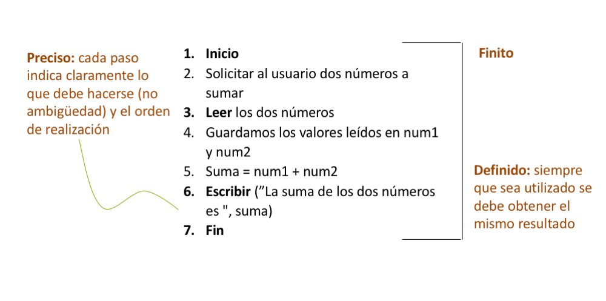

*IMPORTANTE*

- Los **algoritmos** son **independientes** tanto **del lenguaje de programación** como de la **computadora** que los ejecuta, ya que **describe la lógica** que se debe seguir para la solución del problema.
- Cabe señalar, que podemos encontrar más de una forma para solucionar un problema, y cada forma nos dará un algoritmo distinto. En los ejercicios que veremos durante el curso podrás darte cuenta de ello.

#### Palabras utilizadas al diseñar algoritmos

Para hacer más claros y entendibles nuestros algoritmos podemos utilizar ciertas palabras o símbolos que nos permitirán representar acciones específicas.

| Palabra | Descripción |
| --- | --- |
| Inicio | Comienzo del algoritmo |
| Fin | Final del algoritmo |
| Si…. Entonces | Usado para evaluar una condición |
| Haz - Hasta | Agrupa un conjunto de instrucciones a repetir evaluando una condición hasta el final |
| Para | Agrupan un conjunto de instrucciones a repetir un determinado número de veces |
| Leer | Leer un dato desde el teclado |
| Abrir | Abrir archivo |
| Cerrar | Cerrar archivo |
| variable=valor | Guardar un valor con un nombre (variable) |
| // | Comentario |

```
'''NAME
       suma-numeros

VERSION
        1.0

AUTHOR
        Ana Nava <anasofi@gmail.com>

DESCRIPTION
        suma de numeros

CATEGORY
        math

USAGE
        suma-numeros [OPTIONS]

ARGUMENTS
    --version             show program's version number and exit
    -h, --help            show this help message and exit
    -v #, --verbosity=#   set verbosity to level #
                              0 no verbosity
                              1 max verbosity
    -o #, --output=#      output results to #
                          if not specified, the standard output is used
    -i #, --input=#       input file
                          if not specified, the standard input is used


'''

## 1. Leer argumentos

## 2. Leer archivo de datos

## 3. Calcular suma

## 4. Imprimir resultados
```

### 6. FAIR software

“Los principios FAIR son un concepto que se originó en la gestión de datos. El acrónimo significa Localizable, Accesible, Interoperable y Reutilizable. Han servido como buque insignia para promover buenas prácticas de gestión de datos, pero hasta hace poco no eran directamente aplicables al software. Esperamos que los principios FAIR tengan un efecto positivo en el desarrollo de software de investigación.” (https://fair-software.nl/about)

1. Usar un repositorio público y accesible con control de versiones.
2. Agrega una licencia
3. Registra tu código en una comunidad
4. Habilitar la forma de citar el software
5. Usa un lista de verificación de calidad de software

Recomendaciones

##### Gestión de datos

- Guarde los datos brutos.
- Asegúrese de que se haga una copia de seguridad de los datos sin procesar en más de una ubicación.
- Crea los datos que deseas ver en el mundo.
- Cree datos fáciles de analizar.
- Registre todos los pasos utilizados para procesar los datos.
- Anticípese a la necesidad de utilizar varias tablas y utilice un identificador único para cada registro.
- Envíe los datos a un repositorio que emita DOI de buena reputación para que otros puedan acceder y citarlos.

##### Software

- Coloque un breve comentario explicativo al comienzo de cada programa.
- Descomponer programas en funciones.
- Sea implacable en la eliminación de la duplicación.
- Busque siempre bibliotecas de software bien mantenidas que hagan lo que necesita.
- Pruebe las bibliotecas antes de confiar en ellas.
- Asigne nombres significativos a las funciones y variables.
- Haga explícitas las dependencias y los requisitos.
- No comente ni descomente secciones de código para controlar el comportamiento de un programa.
- Proporcione un ejemplo simple o un conjunto de datos de prueba.
- Envíe el código a un repositorio que emita DOI de buena reputación.

### Bibliografía

1. Imelda Avalos Flores. (2010). I. Introducción a la programación. Junio 14, 2017, de Universidad Autónoma de Nayarit Sitio web: http://correo.uan.edu.mx/~iavalos/FP/FP1.html
2. SENA. (2017). Etapas del ciclo de vida. Junio 14, 2017, de wikispaces Sitio web: https://ciclodevidasoftware.wikispaces.com/ETAPAS+DEL+CICLO+DE+VIDA
3. Bernal, L. A.. (Agosto 11, 2014). Cómo hacer una prueba de escritorio. Junio 10, 2017, de aztlek.org Sitio web: https://aztlek.org/2014/08/11/como-hacer-una-prueba-de-escritorio/
4. https://islascruz.org/blog/2018/07/25/buenas-practicas-en-python/
5. https://www.educ.ar/recursos/132522/consejos-y-buenas-practicas-para-programar-en-python
6. https://www.tithink.com/es/2018/06/13/12-buenas-practicas-para-el-desarrollo-software/
7. https://wiki.python.org/moin/PythonTestingToolsTaxonomy
8. ¿Por qué es importante la Ingeniería de Software? https://medium.com/@FunktionellMx/por-qu%C3%A9-es-importante-la-ingenier%C3%ADa-de-software-a4000134f6e2
9. Metodologías de desarrollo de software: ¿qué son? https://blog.becas-santander.com/es/metodologias-desarrollo-software.html
10. Good enough practices in scientific computing. https://journals.plos.org/ploscompbiol/article?id=10.1371/journal.pcbi.1005510

Para generar referencias automáticamente: http://www.cva.itesm.mx/biblioteca/pagina_con_formato_version_oct/apaweb.html